# idopNetwork_vignette

Ang Dong

04/18/2023

```r
library(idopNetwork)
backup_options <- options()
#load pre-computered results
test_result = idopNetwork:::test_result
```

# About

idopNetwork is packed as a cartographic tool that performs power curve fitting, classification, variable selection, microbial abundance decomposition, and network visualization based on microbial 16S rRNA gene sequencing metadata.

**For complete details on the use and execution of this protocol, please refer to [Chen et al](https://doi.org/10.1038/s41540-019-0116-1) and [Cao et al](https://doi.org/10.1080/19490976.2022.2106103).**

# 1. Input data

Before running idopNetwork, user need to provide datasets, and they should be cleaned and merged to exactly the same format of the example data.

## 1.1 gut microbe OTUs data

Microbe Operational taxonomic unit dataset must have first column as IDs for microbes.

```r
data("gut_microbe")
View(gut_microbe)
```

| name | GQ_UC1 | GQ_UC3 | GQ_UC4 | GQ_UC5 |
| --- | --- | --- | --- | --- |
| Escherichia_coli | 176 | 1701 | 28506 | 177 |
| Arthrobacter_oxydans | 3 | 215 | 1578 | 1 |
| Ruminococcus_gnavus | 744 | 0 | 4 | 733 |
| Bacteroides_plebeius | 271 | 4401 | 7 | 8394 |
| Bacteroides_pyogenes | 0 | 15 | 0 | 0 |
| Clostridium_tertium | 305 | 1 | 1 | 270 |
| Bacteroides_stercoris | 24 | 0 | 0 | 11 |
| Flavisolibacter_ginsengisoli | 0 | 123 | 831 | 0 |
| Bacteroides_massiliensis | 0 | 6098 | 6 | 0 |
| Prevotella_heparinolytica | 0 | 6 | 0 | 0 |

## 1.2 mustard microbe OTUs data

```r
data("mustard_microbe")
View(mustard_microbe)
```

|  | ID | 8_0149.leaf | 8_0157.leaf | 8_0158.leaf | 8_0160.leaf |
| --- | --- | --- | --- | --- | --- |
| 2 | OTU_1 | 3 | 2 | 59 | 268 |
| 3 | OTU_2 | 8 | 13 | 1890 | 44 |
| 4 | OTU_3 | 5485 | 3302 | 4522 | 6581 |
| 5 | OTU_4 | 42 | 351 | 7 | 4 |
| 6 | OTU_5 | 16 | 2002 | 24 | 43 |
| 7 | OTU_6 | 1645 | 1170 | 10636 | 31686 |
| 8 | OTU_7 | 4050 | 4094 | 13 | 66 |
| 9 | OTU_8 | 6 | 282 | 124 | 27 |
| 10 | OTU_9 | 102 | 5 | 10 | 18 |
| 11 | OTU_10 | 25 | 1393 | 35 | 19 |

|  | JAM_E4.leaf | 8_0149.root | 8_0157.root | 8_0158.root | 8_0160.root |
| --- | --- | --- | --- | --- | --- |
| 2 | 7 | 28861 | 122 | 1 | 9 |
| 3 | 4 | 11618 | 19 | 14 | 1894 |
| 4 | 4981 | 481 | 755 | 17914 | 15998 |
| 5 | 622 | 862 | 1072 | 11 | 103 |
| 6 | 10014 | 447 | 758 | 19 | 289 |
| 7 | 577 | 1010 | 490 | 25030 | 29443 |
| 8 | 2233 | 13 | 5575 | 26 | 64 |
| 9 | 19 | 3348 | 36 | 33 | 46 |
| 10 | 362 | 6269 | 228 | 2 | 459 |
| 11 | 3071 | 4 | 6454 | 6 | 234 |

# 2. power curve fitting

```r
df = data_cleaning(gut_microbe)
```

```r
result1 = power_equation_fit(df)
```

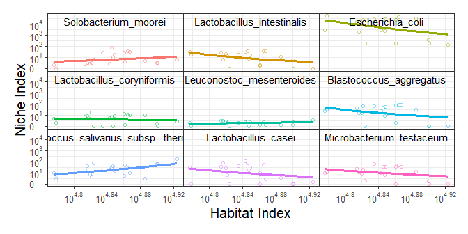

```r
power_equation_plot(result1)
```

# 3. Functional clustering

In this step we implement the power equation into functional clustering to detect different microbial modules. If after clustering there are still too many microbes within a certain module for network reconstruction, we can rerun functional clustering to further classify this module into distinct submodules.

## 3.1 mean curve

we fit mean vector of each cluster center by power equation(assume k=3)

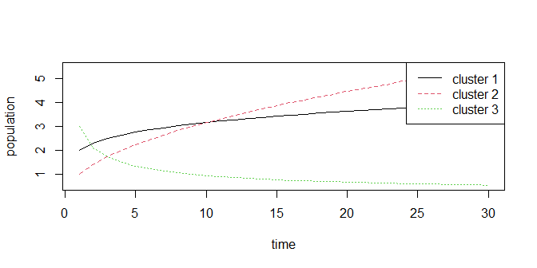

```r
matplot(t(power_equation(x = 1:30, matrix(c(2,1,3,0.2,0.5,-0.5),nrow = 3, ncol = 2))),
        type = "l",
        xlab = "time",
        ylab = "population")
legend("topright",
       c("cluster 1", "cluster 2", "cluster 3"),
       lty = c(1,2,3),
       col = c(1,2,3),
       box.lwd = 0)
```

## 3.2 covariance matrix

we fit covariance matrix of multivariate normal distribution with SAD1, it can be showed as

```r
get_SAD1_covmatrix(c(2,0.5), n = 5)
```

```
#>      [,1]  [,2]  [,3]  [,4]  [,5]
#> [1,] 0.25  0.50  1.00  2.00  4.00
#> [2,] 0.50  1.25  2.50  5.00 10.00
#> [3,] 1.00  2.50  5.25 10.50 21.00
#> [4,] 2.00  5.00 10.50 21.25 42.50
#> [5,] 4.00 10.00 21.00 42.50 85.25
```

## 3.3 initial parameters

we can check initial parameters (k=4)

```r
get_par_int(X = log10(df+1), k = 4, times = as.numeric(log10(colSums(df)+1)))
```

[output not shown]

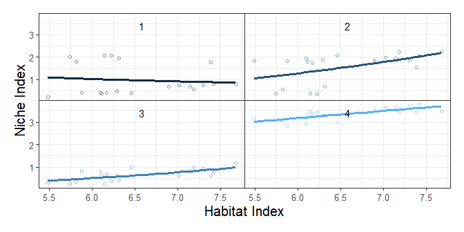

```r
#use kmeans to get initial centers
tmp = kmeans(log10(df+1),4)$centers
tmp2 = power_equation_fit(tmp, trans = NULL)
power_equation_plot(tmp2, label = NULL,n = 4)
```